# ADHD management

## Intervention: Atomoxetine vs Methylphenidate

### Outcome: functional:categorical

Analyzing 0 studies.

No data.

## Intervention: Atomoxetine vs Methylphenidate

### Outcome: cognitive:continuous

No data #1.

## Intervention: Atomoxetine vs Methylphenidate

### Outcome: cognitive:categorical

Analyzing 0 studies.

No data.

## Intervention: Atomoxetine vs Methylphenidate

### Outcome: symptom:continuous

| ID | measure | mean_ctrl_cont | SD_ctrl_cont | n_ctrl_cont | mean_int_cont | SD_int_cont | n_int_cont | yi | se | study.design |
| --- | --- | --- | --- | --- | --- | --- | --- | --- | --- | --- |
| Shim, 2022{#3242} NS-NRI-ATX | ASRS (Adult ADHD Self-Report Scale), change from baseline | 8.469 | 10.907 | 22 | 9.857 | 12.492 | 19 | -0.1166796 | 0.3134520 | RCT |
| Weisler, 2012{#1844} NS-NRI-ATX | ADHD-RS-IV (Attention-Deficit/Hyperactivity Disorder Rating Scale, Version IV) change from baseline | -15.700 | 13.390 | 68 | -15.300 | 14.520 | 73 | 0.0284439 | 0.1685449 | RCT |

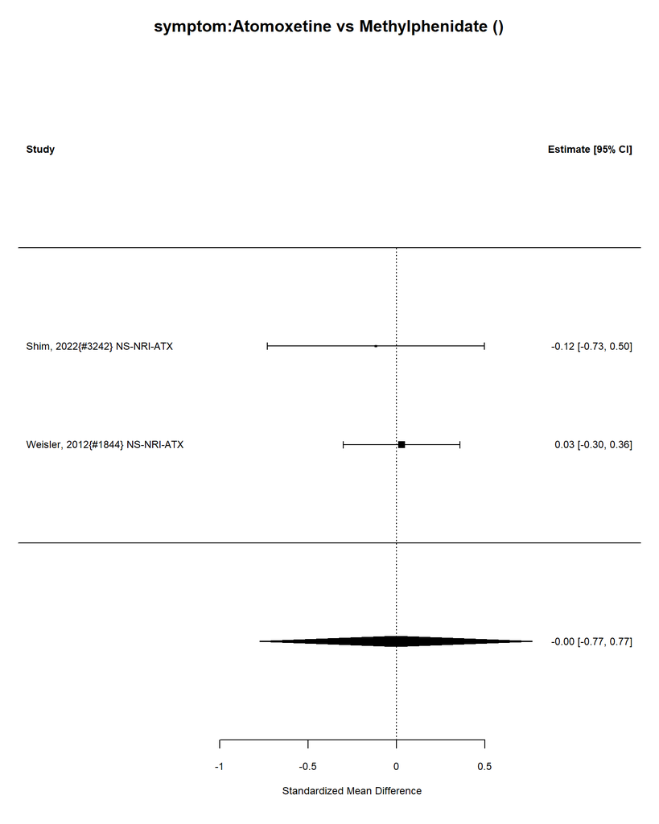

| estimate | conf.low | conf.high |
| --- | --- | --- |
| 0 | -0.77 | 0.77 |

Number of studies = 2

Intervention sample = 92

Control sample = 90

Total sample = 182.

I-squared = 0 %

Convert Effect Size to Real Units

Estimated effect in original units = -0.05.

## Intervention: Atomoxetine vs Methylphenidate

### Outcome: symptom:categorical

Analyzing 0 studies.

No data.

## Intervention: Atomoxetine vs Methylphenidate

### Outcome: substance_use:continuous

No data #1.

## Intervention: Atomoxetine vs Methylphenidate

### Outcome: substance_use:categorical

Analyzing 0 studies.

No data.

## Intervention: Atomoxetine vs Methylphenidate

### Outcome: relationship:continuous

No data #1.

## Intervention: Atomoxetine vs Methylphenidate

### Outcome: relationship:categorical

Analyzing 0 studies.

No data.

## Intervention: Atomoxetine vs Methylphenidate

### Outcome: BP:continuous

| ID | measure | mean_ctrl_cont | SD_ctrl_cont | n_ctrl_cont | mean_int_cont | SD_int_cont | n_int_cont | yi | se | study.design |
| --- | --- | --- | --- | --- | --- | --- | --- | --- | --- | --- |
| Shim, 2022{#3242} NS-NRI-ATX | Systolic blood pressure | 124.4 | 14.4 | 22 | 121.6 | 8.9 | 19 | -0.2255362 | 0.3141758 | RCT |

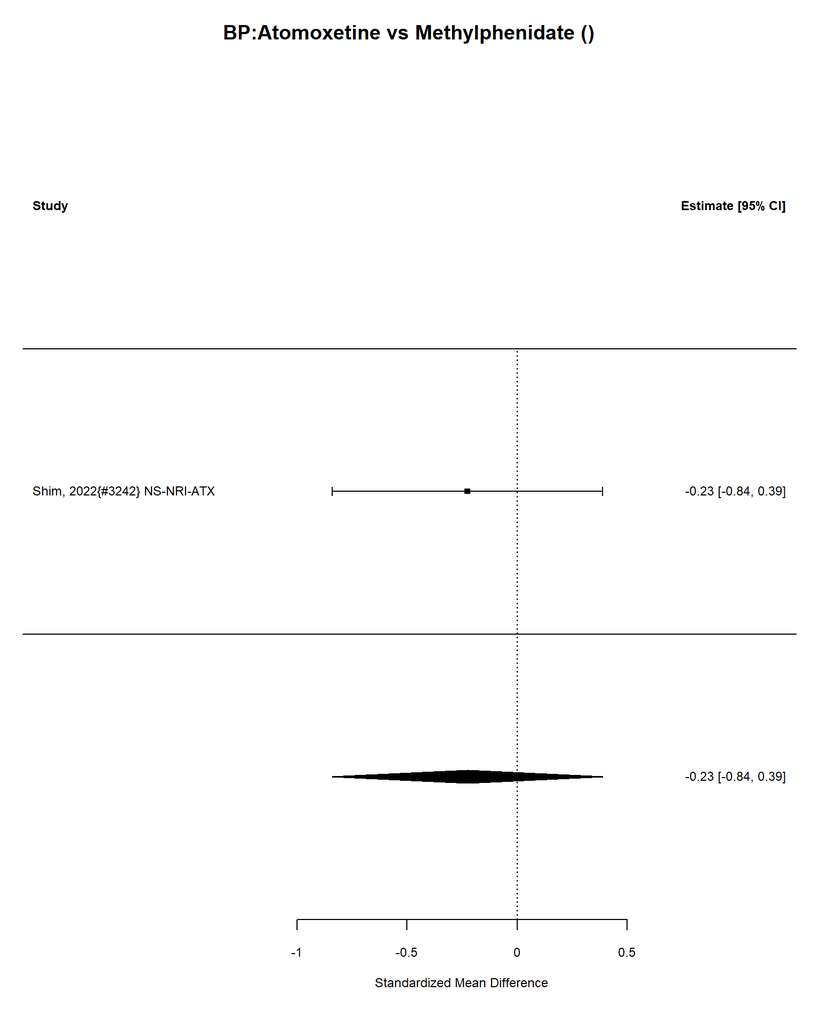

| estimate | conf.low | conf.high |
| --- | --- | --- |
| -0.23 | -0.84 | 0.39 |

Number of studies = 1

Intervention sample = 19

Control sample = 22

Total sample = 41.

I-squared = 0 %

Convert Effect Size to Real Units

Estimated effect in original units = -3.25.

## Intervention: Atomoxetine vs Methylphenidate

### Outcome: BP:categorical

Analyzing 0 studies.

No data.

## Intervention: Atomoxetine vs Methylphenidate

### Outcome: sleep_disturbance:continuous

No data #1.

## Intervention: Atomoxetine vs Methylphenidate

### Outcome: sleep_disturbance:categorical

Analyzing 1 studies.

Analyzing 1 studies.

### Control Types

| control | n |
| --- | --- |
| Placebo | 1 |

| ID | measure | yi | se | study.design |
| --- | --- | --- | --- | --- |
| Weisler, 2012{#1844} NS-NRI-ATX | Number of participants reporting insomnia | -1.47 | 1.11 | RCT |

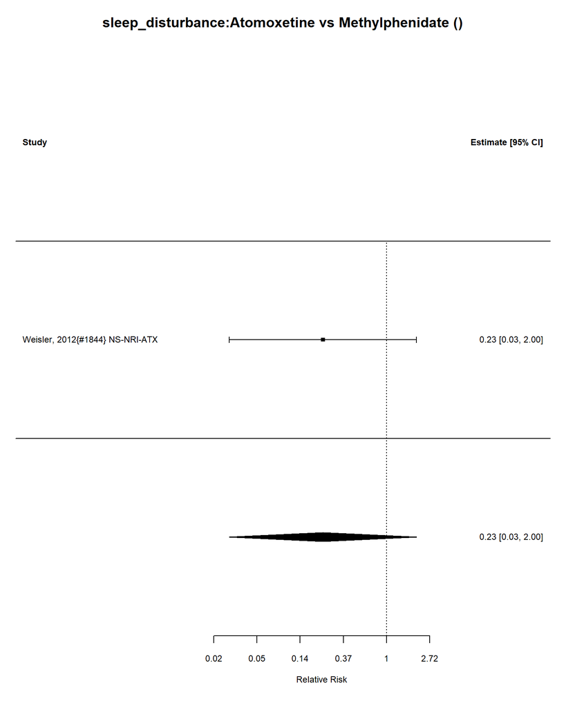

Number of studies = 1  
Intervention sample = 74  
Control sample = 73  
Total sample = 147

### Relative Risk Estimate

|  | estimate | se | zval | pval | ci.lb | ci.ub |
| --- | --- | --- | --- | --- | --- | --- |
| intrcpt | 0.2299255 | 3.034358 | 0.2644773 | 1.197217 | 0.0262523 | 2.013753 |

I-squared = 0 %

## Intervention: Atomoxetine vs Methylphenidate

### Outcome: AEs:continuous

No data #1.

## Intervention: Atomoxetine vs Methylphenidate

### Outcome: AEs:categorical

Analyzing 1 studies.

Analyzing 1 studies.

### Control Types

| control | n |
| --- | --- |
| Placebo | 1 |

| ID | measure | yi | se | study.design |
| --- | --- | --- | --- | --- |
| Weisler, 2012{#1844} NS-NRI-ATX | Number of participants reporting any adverse events | 0.02 | 0.08 | RCT |

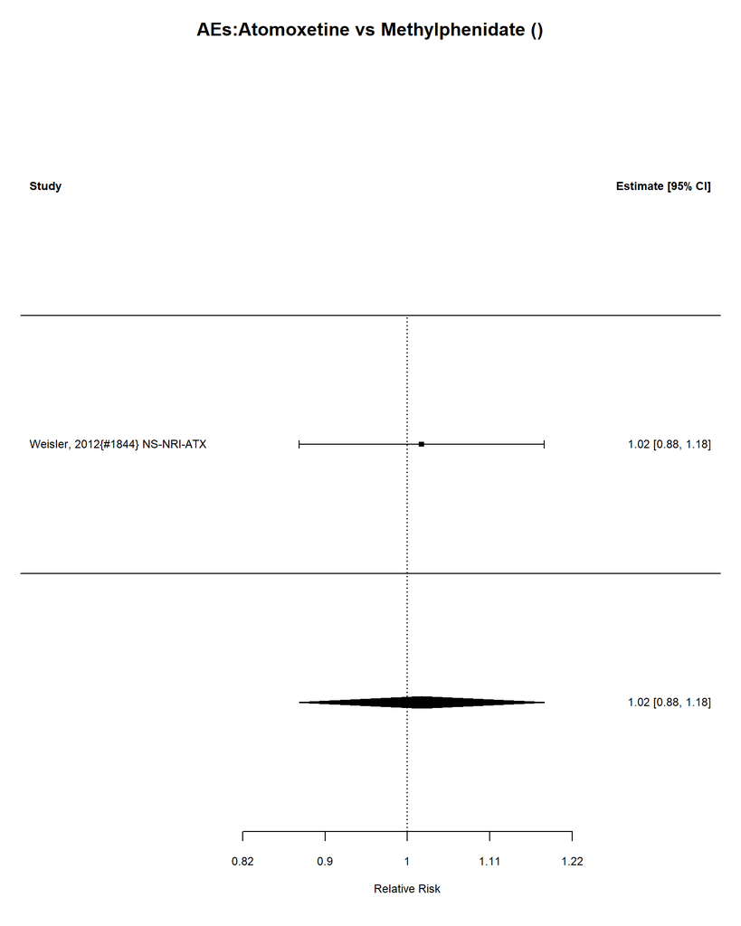

Number of studies = 1  
Intervention sample = 74  
Control sample = 73  
Total sample = 147

### Relative Risk Estimate

|  | estimate | se | zval | pval | ci.lb | ci.ub |
| --- | --- | --- | --- | --- | --- | --- |
| intrcpt | 1.020201 | 1.083287 | 1.2586 | 2.2705 | 0.8780954 | 1.185305 |

I-squared = 0 %

## Intervention: Atomoxetine vs Methylphenidate

### Outcome: mortality:continuous

No data #1.

## Intervention: Atomoxetine vs Methylphenidate

### Outcome: mortality:categorical

Analyzing 1 studies.

Analyzing 1 studies.

### Control Types

| control | n |
| --- | --- |
| Placebo | 1 |

| ID | measure | yi | se | study.design |
| --- | --- | --- | --- | --- |
| Weisler, 2012{#1844} NS-NRI-ATX | Number of deaths | 0.08 | 1.99 | RCT |

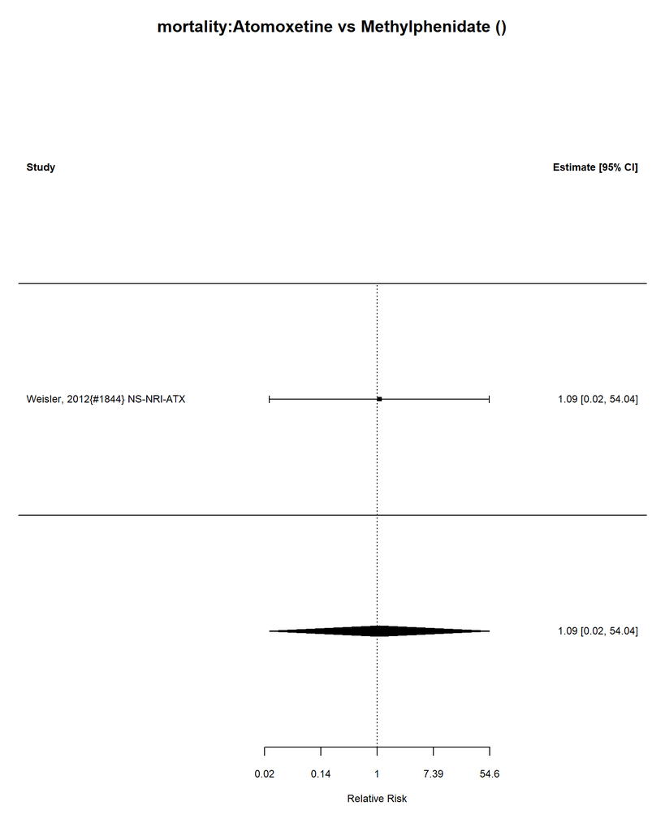

Number of studies = 1  
Intervention sample = 74  
Control sample = 73  
Total sample = 147

### Relative Risk Estimate

|  | estimate | se | zval | pval | ci.lb | ci.ub |
| --- | --- | --- | --- | --- | --- | --- |
| intrcpt | 1.083287 | 7.315534 | 1.040811 | 2.637945 | 0.0219278 | 54.05489 |

I-squared = 0 %

## Intervention: Atomoxetine vs Methylphenidate

### Outcome: behavior:continuous

No data #1.

## Intervention: Atomoxetine vs Methylphenidate

### Outcome: behavior:categorical

Analyzing 0 studies.

No data.

## Intervention: Atomoxetine vs Methylphenidate

### Outcome: appetite:continuous

No data #1.

## Intervention: Atomoxetine vs Methylphenidate

### Outcome: appetite:categorical

Analyzing 1 studies.

Analyzing 1 studies.

### Control Types

| control | n |
| --- | --- |
| Placebo | 1 |

| ID | measure | yi | se | study.design |
| --- | --- | --- | --- | --- |
| Weisler, 2012{#1844} NS-NRI-ATX | Decreased appetite adverse event | -0.8 | 0.42 | RCT |

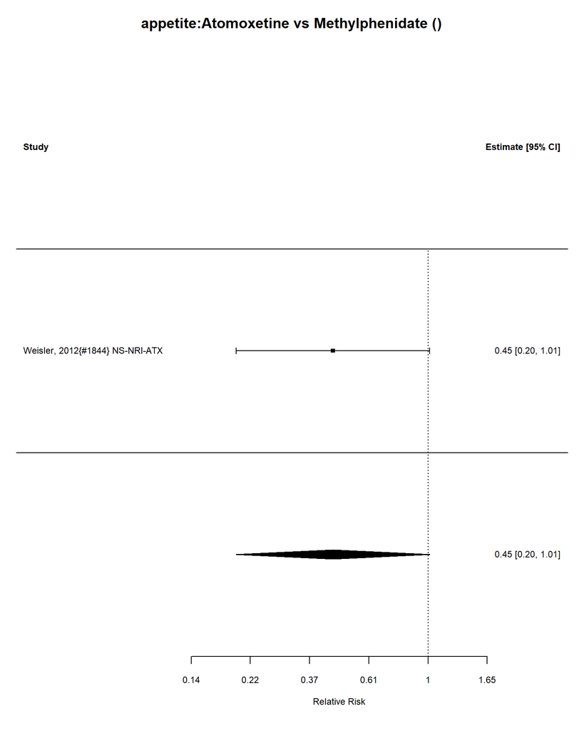

Number of studies = 1  
Intervention sample = 74  
Control sample = 73  
Total sample = 147

### Relative Risk Estimate

|  | estimate | se | zval | pval | ci.lb | ci.ub |
| --- | --- | --- | --- | --- | --- | --- |
| intrcpt | 0.449329 | 1.521962 | 0.1451482 | 1.051271 | 0.1978987 | 1.01005 |

I-squared = 0 %

## Intervention: Atomoxetine vs Methylphenidate

### Outcome: mood:continuous

No data #1.

## Intervention: Atomoxetine vs Methylphenidate

### Outcome: mood:categorical

Analyzing 0 studies.

No data.